# Project: Investigate a Dataset (TMDB Movie Database)

- Introduction
- Data Wrangling
- Exploratory Data Analysis
- Conclusions

## Introduction

For my project report, I analysed a dataset obtained from the TMDB Movie Database (TMDb). This data contains details on approximately 10,000 movies produced from 1960 to 2015. The dataset contains 21 columns as shown below:

```
1. id - a unique random identifier used to identify each movie
2. imdb_id - a unique official alphanumeric identifier which is can be used to google each movie
3. popularity - a numeric value assigned to each movie signifying how popular the movie is
4. budget - dollar value attributing how much was spent to produce each movie
5. revenue - dollar value attributing how much was earned in sales from each movie
6. original_title - signifies the official name used to identify each movie
7. cast - displays a list of the top 5 actors/actresses in each movie
8. homepage - contains a link to the movie website
9. director - indivual(s) responsible for directing the movie
10. tagline - a short description or comment unique to each movie
11. keywords - word(s) associated with the movie title and can be used to search for the movie
12. overview - a short description on what each movie is about
13. runtime - signifies the lenght of the movie in minutes
14. genres - categorization of what type of movie it is
15. production_companies - the name of the company associated with producing wach movie
16. release_date - date each movie was produced (in format mm/dd/yy)
17. vote_count - total votes each movie received used by users
18. vote_average - rating received by each movie based on average vote count
19. release_year - year each movie was produced
20. budget_adj - dollar value of budget in terms of 2010 dollars, accounting for inflation over time
21. revenue_adj - dollar value of revenue in terms of 2010 dollars, accounting for inflation over time
```

### Questions for Analysis

```
1. Most popular movie in each release_year?
2. Highest revenue generated in each release year?
3. Is there a correlation between popularity and revenue?
4. Have movie length(runtime) increased over the years?
```

### Packages used in the analysis

```python
import pandas as pd
import numpy as np
import seaborn as sns
import matplotlib.pyplot as plt
%matplotlib inline
```

## Data Wrangling

### General Properties

```python
#print a few rows of the dataset to get familiar with the columns
pd.set_option('display.max_columns', None)
df = pd.read_csv('imdb_movies.csv')
df.head(3)
```

[output not shown]

```python
#get basic stats about the dataset
df.describe()
```

|  | id | popularity | budget | revenue | runtime | vote_count | vote_average | release_year | budget_adj | revenue_adj |
| --- | --- | --- | --- | --- | --- | --- | --- | --- | --- | --- |
| count | 10866.000000 | 10866.000000 | 1.086600e+04 | 1.086600e+04 | 10866.000000 | 10866.000000 | 10866.000000 | 10866.000000 | 1.086600e+04 | 1.086600e+04 |
| mean | 66064.177434 | 0.646441 | 1.462570e+07 | 3.982332e+07 | 102.070863 | 217.389748 | 5.974922 | 2001.322658 | 1.755104e+07 | 5.136436e+07 |
| std | 92130.136561 | 1.000185 | 3.091321e+07 | 1.170035e+08 | 31.381405 | 575.619058 | 0.935142 | 12.812941 | 3.430616e+07 | 1.446325e+08 |
| min | 5.000000 | 0.000065 | 0.000000e+00 | 0.000000e+00 | 0.000000 | 10.000000 | 1.500000 | 1960.000000 | 0.000000e+00 | 0.000000e+00 |
| 25% | 10596.250000 | 0.207583 | 0.000000e+00 | 0.000000e+00 | 90.000000 | 17.000000 | 5.400000 | 1995.000000 | 0.000000e+00 | 0.000000e+00 |
| 50% | 20669.000000 | 0.383856 | 0.000000e+00 | 0.000000e+00 | 99.000000 | 38.000000 | 6.000000 | 2006.000000 | 0.000000e+00 | 0.000000e+00 |
| 75% | 75610.000000 | 0.713817 | 1.500000e+07 | 2.400000e+07 | 111.000000 | 145.750000 | 6.600000 | 2011.000000 | 2.085325e+07 | 3.369710e+07 |
| max | 417859.000000 | 32.985763 | 4.250000e+08 | 2.781506e+09 | 900.000000 | 9767.000000 | 9.200000 | 2015.000000 | 4.250000e+08 | 2.827124e+09 |

```python
#identify no. of columns and rows in dataset(columns, rows)
df.shape
```

```
(10866, 21)
```

```python
#identify datatypes contained in dataset
df.dtypes
```

```
id                        int64
imdb_id                  object
popularity              float64
budget                    int64
revenue                   int64
original_title           object
cast                     object
homepage                 object
director                 object
tagline                  object
keywords                 object
overview                 object
runtime                   int64
genres                   object
production_companies     object
release_date             object
vote_count                int64
vote_average            float64
release_year              int64
budget_adj              float64
revenue_adj             float64
dtype: object
```

```python
#are there duplicate rows in the dataset? [0 = no duplicates]
df.duplicated().sum()
```

```
1
```

```python
#are there null values in the dataset?
df.isnull().sum()
```

```
id                         0
imdb_id                   10
popularity                 0
budget                     0
revenue                    0
original_title             0
cast                      76
homepage                7930
director                  44
tagline                 2824
keywords                1493
overview                   4
runtime                    0
genres                    23
production_companies    1030
release_date               0
vote_count                 0
vote_average               0
release_year               0
budget_adj                 0
revenue_adj                0
dtype: int64
```

```python
#how many unique values are in each column?
df.nunique()
```

```
id                      10865
imdb_id                 10855
popularity              10814
budget                    557
revenue                  4702
original_title          10571
cast                    10719
homepage                 2896
director                 5067
tagline                  7997
keywords                 8804
overview                10847
runtime                   247
genres                   2039
production_companies     7445
release_date             5909
vote_count               1289
vote_average               72
release_year               56
budget_adj               2614
revenue_adj              4840
dtype: int64
```

# Interesting facts from dataset

```python
# Top 10 production companies by movies count
pd.options.display.max_rows = 9999
df2 = df.groupby(df['production_companies'])['production_companies'].count().sort_values(ascending = False)
df2.sort_values(ascending = False).head(10)
```

```
production_companies
Paramount Pictures                        156
Universal Pictures                        133
Warner Bros.                               84
Walt Disney Pictures                       76
Metro-Goldwyn-Mayer (MGM)                  72
Columbia Pictures                          72
New Line Cinema                            61
Touchstone Pictures                        51
20th Century Fox                           50
Twentieth Century Fox Film Corporation     49
Name: production_companies, dtype: int64
```

1. Paramount Pictures produced the most number of movies with 156 movies

```python
#Top 10 directors by movie count
pd.options.display.max_rows = 9999
df2 = df.groupby(df['director'])['director'].count().sort_values(ascending = False)
df2.sort_values(ascending = False).head(10)
```

```
director
Woody Allen          45
Clint Eastwood       34
Steven Spielberg     29
Martin Scorsese      29
Ridley Scott         23
Steven Soderbergh    22
Ron Howard           22
Joel Schumacher      21
Brian De Palma       20
Barry Levinson       19
Name: director, dtype: int64
```

1. Woody Allen directed the most number of movies with 45 movies

### Data Cleaning

#### Dataset has 21 columns and 10,866 rows. 9 of these columns contain some null values.

#### Dataset also contained 1 duplicated row.

```python
#delete duplicated row and confirm
df.drop_duplicates(inplace=True)
df.duplicated().count()
```

```
10865
```

#### One less row in the row total signifies that duplicated row was successfully deleted

To answer my research questions above, certain columns have no analytical advantages thus the analysis would not require them. These columns would be conveniently dropped.

```python
#Drop the following columns: ['imdb_id','homepage','tagline','overview','release_date','keywords'])
df1 = df.drop(columns=['imdb_id','homepage','tagline','overview','release_date','keywords'])
```

```python
#confirm that columns have been successfully dropped
df1.head(1)
```

|  | id | popularity | budget | revenue | original_title | cast | director | runtime | genres | production_companies | vote_count | vote_average | release_year | budget_adj | revenue_adj |
| --- | --- | --- | --- | --- | --- | --- | --- | --- | --- | --- | --- | --- | --- | --- | --- |
| 0 | 135397 | 32.985763 | 150000000 | 1513528810 | Jurassic World | Chris Pratt\|Bryce Dallas Howard\|Irrfan Khan\|Vi... | Colin Trevorrow | 124 | Action\|Adventure\|Science Fiction\|Thriller | Universal Studios\|Amblin Entertainment\|Legenda... | 5562 | 6.5 | 2015 | 1.379999e+08 | 1.392446e+09 |

```python
df1.isnull().sum()
```

```
id                         0
popularity                 0
budget                     0
revenue                    0
original_title             0
cast                      76
director                  44
runtime                    0
genres                    23
production_companies    1030
vote_count                 0
vote_average               0
release_year               0
budget_adj                 0
revenue_adj                0
dtype: int64
```

### Rather than drop the rows with null values, i decided to replace these fields with the string 'unknown' to avoid diluting the dataset

```python
df1["cast"].fillna("cast unknown", inplace = True)
df1['director'].fillna('director unknown', inplace = True)
df1['genres'].fillna('genre unknown', inplace = True)
df1['production_companies'].fillna('prodco unknown', inplace = True)
```

```python
#confirm that null value count is now zero(0)
df1.isnull().sum()
```

```
id                      0
popularity              0
budget                  0
revenue                 0
original_title          0
cast                    0
director                0
runtime                 0
genres                  0
production_companies    0
vote_count              0
vote_average            0
release_year            0
budget_adj              0
revenue_adj             0
dtype: int64
```

```python
#confirm final column and row count for analysis
df.shape
```

```
(10865, 21)
```

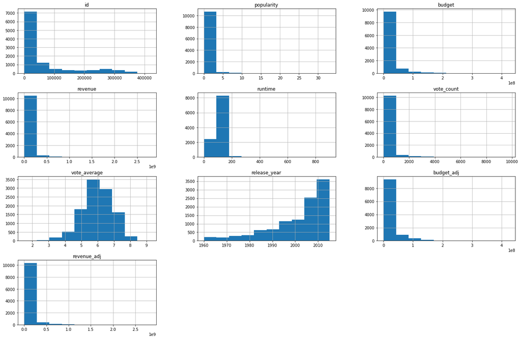

```python
df1.hist(figsize=(23,15));
```

## Exploratory Data Analysis

## Research Question 1. Most popular movie in each release year?

```python
pd.options.display.max_rows = 9999

#columns needed are original title, release year and popularity
mostpopular = df[['original_title','release_year','popularity']].sort_values(by=['release_year','popularity'], ascending = False)

#sort the list according to release year and then by popularity ranking
sorted = mostpopular.sort_values(by=['release_year','popularity'], ascending = False)

#delete duplicates to maintain only the most popular movie in each year
result = sorted.drop_duplicates('release_year', keep='first').values

df2 = pd.DataFrame(result, columns = ['Movie_title','Release_year','Popularity'])
df2
```

|  | Movie_title | Release_year | Popularity |
| --- | --- | --- | --- |
| 0 | Jurassic World | 2015 | 32.99 |
| 1 | Interstellar | 2014 | 24.95 |
| 2 | Frozen | 2013 | 6.11 |
| 3 | The Avengers | 2012 | 7.64 |
| 4 | Underworld: Endless War | 2011 | 8.41 |
| 5 | Inception | 2010 | 9.36 |
| 6 | Avatar | 2009 | 9.43 |
| 7 | The Dark Knight | 2008 | 8.47 |
| 8 | Pirates of the Caribbean: At World's End | 2007 | 4.97 |
| 9 | Underworld: Evolution | 2006 | 5.84 |
| 10 | Harry Potter and the Goblet of Fire | 2005 | 5.94 |
| 11 | Harry Potter and the Prisoner of Azkaban | 2004 | 5.83 |
| 12 | The Lord of the Rings: The Return of the King | 2003 | 7.12 |
| 13 | The Lord of the Rings: The Two Towers | 2002 | 8.10 |
| 14 | The Lord of the Rings: The Fellowship of the Ring | 2001 | 8.58 |
| 15 | Gladiator | 2000 | 4.27 |
| 16 | Fight Club | 1999 | 8.95 |
| 17 | The Truman Show | 1998 | 4.18 |
| 18 | Eddie Izzard: Glorious | 1997 | 6.67 |
| 19 | Independence Day | 1996 | 4.48 |
| 20 | Se7en | 1995 | 4.77 |
| 21 | Pulp Fiction | 1994 | 8.09 |
| 22 | Groundhog Day | 1993 | 2.57 |
| 23 | Reservoir Dogs | 1992 | 4.59 |
| 24 | Beauty and the Beast | 1991 | 3.85 |
| 25 | Total Recall | 1990 | 2.68 |
| 26 | The Little Mermaid | 1989 | 4.14 |
| 27 | Die Hard | 1988 | 3.78 |
| 28 | Predator | 1987 | 3.47 |
| 29 | Aliens | 1986 | 2.49 |
| 30 | Back to the Future | 1985 | 6.10 |
| 31 | The Terminator | 1984 | 4.83 |
| 32 | Return of the Jedi | 1983 | 4.83 |
| 33 | Blade Runner | 1982 | 4.22 |
| 34 | Raiders of the Lost Ark | 1981 | 4.58 |
| 35 | The Empire Strikes Back | 1980 | 5.49 |
| 36 | Alien | 1979 | 4.94 |
| 37 | Grease | 1978 | 1.70 |
| 38 | Star Wars | 1977 | 12.04 |
| 39 | Taxi Driver | 1976 | 2.58 |
| 40 | One Flew Over the Cuckoo's Nest | 1975 | 3.26 |
| 41 | The Godfather: Part II | 1974 | 3.26 |
| 42 | Robin Hood | 1973 | 2.27 |
| 43 | The Godfather | 1972 | 5.74 |
| 44 | A Clockwork Orange | 1971 | 3.07 |
| 45 | The Aristocats | 1970 | 1.94 |
| 46 | On Her Majesty's Secret Service | 1969 | 1.78 |
| 47 | 2001: A Space Odyssey | 1968 | 3.31 |
| 48 | The Jungle Book | 1967 | 2.55 |
| 49 | How the Grinch Stole Christmas! | 1966 | 1.23 |
| 50 | Thunderball | 1965 | 1.91 |
| 51 | Goldfinger | 1964 | 3.15 |
| 52 | From Russia With Love | 1963 | 2.51 |
| 53 | Dr. No | 1962 | 3.17 |
| 54 | One Hundred and One Dalmatians | 1961 | 2.63 |
| 55 | Psycho | 1960 | 2.61 |

### Dataframe above shows the most popular movie each year over the period 1960 - 2015. Coincidentally, the most popular movie in 2015 (Jurassic World) was also the overall most popular movie for the analysis period with a popularity score of 32.9.

## Research Question 2. Highest revenue generated in each release year?

```python
#columns needed are original title, release year
top_rev = df[['original_title','release_year','revenue_adj']]

sorted = top_rev.sort_values(by=['release_year','revenue_adj'], ascending = False)
result = sorted.drop_duplicates('release_year', keep='first').values
df3 = pd.DataFrame(result, columns = ['Movie_title','Release_year','Revenue ($)'])

#format revenue column with '000 separators
pd.options.display.float_format = '{:,.2f}'.format
df3
```

|  | Movie_title | Release_year | Revenue ($) |
| --- | --- | --- | --- |
| 0 | Star Wars: The Force Awakens | 2015 | 1,902,723,129.80 |
| 1 | The Hobbit: The Battle of the Five Armies | 2014 | 879,752,289.14 |
| 2 | Frozen | 2013 | 1,192,711,491.12 |
| 3 | The Avengers | 2012 | 1,443,191,435.21 |
| 4 | Harry Potter and the Deathly Hallows: Part 2 | 2011 | 1,287,183,997.56 |
| 5 | Toy Story 3 | 2010 | 1,063,171,911.00 |
| 6 | Avatar | 2009 | 2,827,123,750.41 |
| 7 | The Dark Knight | 2008 | 1,014,733,032.48 |
| 8 | Pirates of the Caribbean: At World's End | 2007 | 1,010,653,507.91 |
| 9 | Pirates of the Caribbean: Dead Man's Chest | 2006 | 1,152,691,351.87 |
| 10 | Harry Potter and the Goblet of Fire | 2005 | 1,000,352,539.23 |
| 11 | Shrek 2 | 2004 | 1,061,903,622.74 |
| 12 | The Lord of the Rings: The Return of the King | 2003 | 1,326,278,010.48 |
| 13 | The Lord of the Rings: The Two Towers | 2002 | 1,122,902,454.42 |
| 14 | Harry Potter and the Philosopher's Stone | 2001 | 1,202,518,036.07 |
| 15 | Mission: Impossible II | 2000 | 691,886,948.73 |
| 16 | Star Wars: Episode I - The Phantom Menace | 1999 | 1,209,980,530.46 |
| 17 | Armageddon | 1998 | 740,815,170.22 |
| 18 | Titanic | 1997 | 2,506,405,735.42 |
| 19 | Independence Day | 1996 | 1,135,764,351.59 |
| 20 | The Net | 1995 | 1,583,049,536.35 |
| 21 | The Lion King | 1994 | 1,159,591,590.01 |
| 22 | Jurassic Park | 1993 | 1,388,863,311.76 |
| 23 | Aladdin | 1992 | 783,306,265.86 |
| 24 | Terminator 2: Judgment Day | 1991 | 832,568,277.80 |
| 25 | Ghost | 1990 | 842,793,762.86 |
| 26 | Indiana Jones and the Last Crusade | 1989 | 834,061,065.27 |
| 27 | Rain Man | 1988 | 654,259,434.36 |
| 28 | Fatal Attraction | 1987 | 614,385,336.77 |
| 29 | Top Gun | 1986 | 709,881,085.22 |
| 30 | Back to the Future | 1985 | 772,572,771.71 |
| 31 | Indiana Jones and the Temple of Doom | 1984 | 698,980,999.05 |
| 32 | Return of the Jedi | 1983 | 1,253,818,981.12 |
| 33 | E.T. the Extra-Terrestrial | 1982 | 1,791,694,309.25 |
| 34 | Raiders of the Lost Ark | 1981 | 935,116,878.23 |
| 35 | The Empire Strikes Back | 1980 | 1,424,626,187.77 |
| 36 | Moonraker | 1979 | 631,857,706.73 |
| 37 | Superman | 1978 | 1,003,538,977.39 |
| 38 | Star Wars | 1977 | 2,789,712,242.28 |
| 39 | A Star Is Born | 1976 | 616,903,382.58 |
| 40 | Jaws | 1975 | 1,907,005,841.92 |
| 41 | Blazing Saddles | 1974 | 528,462,924.68 |
| 42 | The Exorcist | 1973 | 2,167,324,901.20 |
| 43 | The Godfather | 1972 | 1,277,913,732.39 |
| 44 | Diamonds Are Forever | 1971 | 624,682,610.07 |
| 45 | Love Story | 1970 | 766,072,642.11 |
| 46 | Butch Cassidy and the Sundance Kid | 1969 | 608,151,066.34 |
| 47 | 2001: A Space Odyssey | 1968 | 355,546,597.21 |
| 48 | The Jungle Book | 1967 | 1,345,551,058.99 |
| 49 | Who's Afraid of Virginia Woolf? | 1966 | 226,643,572.37 |
| 50 | The Sound of Music | 1965 | 1,129,534,861.99 |
| 51 | Goldfinger | 1964 | 878,080,399.54 |
| 52 | From Russia With Love | 1963 | 561,773,358.99 |
| 53 | Lawrence of Arabia | 1962 | 504,591,421.51 |
| 54 | One Hundred and One Dalmatians | 1961 | 1,574,814,739.70 |
| 55 | Spartacus | 1960 | 442,378,047.43 |